# Writing Functions in R

February 10th, 2021

## Outline

- What are functions?
- Writing your own functions
- Debugging
- Pitfalls

## Why Functions?

- Reduce the amount of copy & pasting required
  - Reduces the chances of making a mistake
- Let computers do what they do best: repetitive tasks
- Code is more readable

## Functions

- You have used functions in the past like `sum()`, `mean()`, `filter()`
- Under the hood these are powered by lines of R code
- You can see this by going command + click the function name
- Does not work for all functions (ie base R)

```r
filter()
mean()
```

## Basic Structure

```r
name_of_function <- function(ingredient_1) {
  # Body of your function
  # Where your R code goes
  # "Recipe goes here"
}
```

## 🍰

### Recipe

Pumpkin Pie 🎃

Ingredients:

- Pumpkin
- Egg
- Pie Crust

Recipe:

- Preheat the oven to 350 F
- Whisk together pumpkin, egg
- Pour mixture into pie crust

### R code

```r
Pumpkin_pie <- function(pumpkin, p_crust) {
# 1. Preheat the oven to 350F
# 2. Whisk together pumpkin, egg
# 3. Pour mixture into crust
# Makes a pi - automatically `returns`
# its result
}
```

## Example Function for Area

```r
# Fill in the template
# Variables in your arguments can be referenced in your body
tri_area <- function(height, base) {
  height * base / 2
}
# Running it will give you a new function in your environment

tri_area(1, 5)
```

```
[1] 2.5
```

## Rule of Thumb for Implementing Functions

If you need to copy/paste code more than 3 times you should start thinking about writing a function (DRY principle; **D**on’t **R**epeat **Y**ourself)

## Tips for Writing Functions

[figure not shown]

## General Steps

- Write some working R code
- Put code into the function format
- Test it
- Fix it until it works

## Challenge 1

Write a function that:

- Takes the width, depth and height as inputs
- Calculates the volume of a rectangular prism
- Call your function `vol_rect`

## Debugging with Specialized Functions

- `debug()`
- `browser()`
- RStudio “red dot” debugger

## Debugging with Print

```r
debug <- function(height, base){
  1 + 2
  height * base / 2
}
debug(1,2)
```

```
[1] 1
```

```r
debug2 <- function(height, base) {
  print(1 + 2)
  height * base / 2
}
debug2(1,2)
```

```
[1] 3
```

```
[1] 1
```

## Pitfalls

- Tidy Evaluation (we will focus on this)
- Lexical Scoping (look this up later)

## Pitfalls - Tidy Evaluation

Trying this for ggplot2, using the built-in **mtcars** dataset

```r
data("mtcars")
mtcars
```

```
                   mpg cyl  disp  hp drat    wt  qsec vs am gear carb
Mazda RX4         21.0   6 160.0 110 3.90 2.620 16.46  0  1    4    4
Mazda RX4 Wag     21.0   6 160.0 110 3.90 2.875 17.02  0  1    4    4
Datsun 710        22.8   4 108.0  93 3.85 2.320 18.61  1  1    4    1
Hornet 4 Drive    21.4   6 258.0 110 3.08 3.215 19.44  1  0    3    1
Hornet Sportabout 18.7   8 360.0 175 3.15 3.440 17.02  0  0    3    2
Valiant           18.1   6 225.0 105 2.76 3.460 20.22  1  0    3    1
Duster 360        14.3   8 360.0 245 3.21 3.570 15.84  0  0    3    4
Merc 240D         24.4   4 146.7  62 3.69 3.190 20.00  1  0    4    2
Merc 230          22.8   4 140.8  95 3.92 3.150 22.90  1  0    4    2
 [ reached 'max' / getOption("max.print") -- omitted 23 rows ]
```

## But the function below doesn’t work!

```r
# Normal ggplot2 call:
ggplot(mtcars, aes(x = mpg, y = wt)) +
  geom_point()

# Function to perform the above:
multi_graph <- function(cx, cy){
  ggplot(mtcars, aes(x = cx, y = cy)) +
    geom_point()
}

# Try it for yourself!
multi_graph(mpg, wt)
```

## Tidyeval to the Rescue

Solution: Put a {{}} around everything!

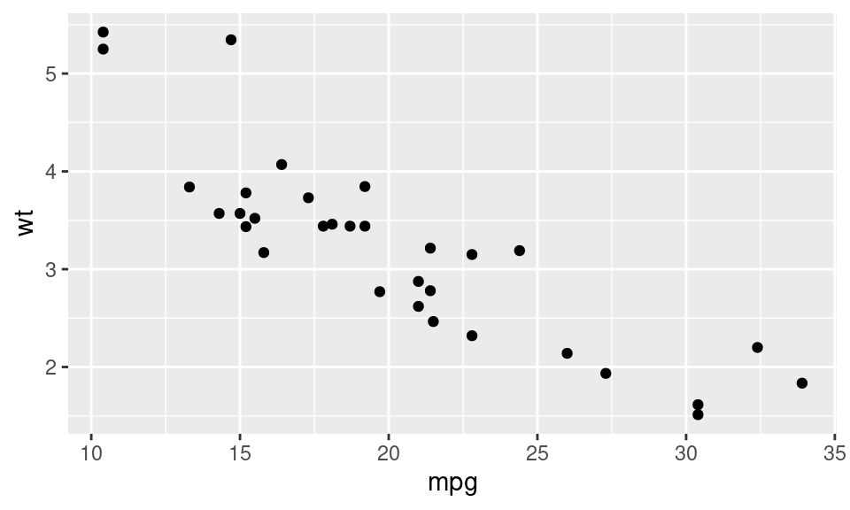

```r
multi_graph_2 <- function(cx, cy) {
  ggplot(mtcars, aes(x = {{cx}}, y = {{cy}})) +
    geom_point()
}
multi_graph_2(mpg, wt)
```

## Challenge 2

Create a function that:

- Will plot a graph of any column in the mtcars dataset
- Saves the box plot under any name given (hint: use `ggsave()`)